# Superfast Likelihood Inference for Stationary Gaussian Time Series

Yun Ling, Martin Lysy

2020-09-21

This vignette illustrates the basic functionality of the **SuperGauss** package by simulating a few stochastic processes and estimating their parameters from regularly spaced data.

## Simulation of Fractional Brownian Motion

A one-dimensional fractional Brownian motion (fBM) $X_t = X(t)$ is a continuous Gaussian process with $E[X_t] = 0$ and $\mathrm{cov}(X_t, X_s) = \tfrac 1 2 (|t|^{2H} + |s|^{2H} - |t-s|^{2H})$, for $0 < H < 1$. fBM is not stationary but has stationary increments, such that $(X_{t+\Delta t} - X_t) \stackrel{D}{=} (X_{s+\Delta t} - X_s)$ for any $s,t$. As such, its covariance function is completely determined its mean squared displacement (MSD)
$$\mathrm{\scriptsize MSD}_X(t) = E[(X_t - X_0)^2] = |t|^{2H}.$$
When the Hurst parameter $H = \tfrac 1 2$, fBM reduces to ordinary Brownian motion.

The following **R** code generates 5 independent fBM realizations of length $N = 5000$ with $H = 0.3$. The timing of the “superfast” method (Wood and Chan 1994) provided in this package is compared to that of a “fast” method (e.g., Brockwell and Davis 1991) and to the usual method (Cholesky decomposition of an unstructured variance matrix).

```r
require(SuperGauss)

N <- 5000 # number of observations
dT <- 1/60 # time between observations (seconds)
H <- .3 # Hurst parameter

tseq <- (0:N)*dT # times at which to sample fBM
npaths <- 5 # number of fBM paths to generate

# to generate fbm, generate its increments, which are stationary
msd <- fbm_msd(tseq = tseq[-1], H = H)
acf <- msd2acf(msd = msd) # convert msd to acf

# superfast method
system.time({
  dX <- rnormtz(n = npaths, acf = acf, fft = TRUE)
})
```

```
##    user  system elapsed
##   0.012   0.002   0.014
```

```r
# fast method (about 3x as slow)
system.time({
  rnormtz(n = npaths, acf = acf, fft = FALSE)
})
```

```
##    user  system elapsed
##   0.055   0.000   0.056
```

```r
# unstructured variance method (much slower)
system.time({
  matrix(rnorm(N*npaths), npaths, N) %*% chol(toeplitz(acf))
})
```

```
##    user  system elapsed
##  17.357   0.244  17.611
```

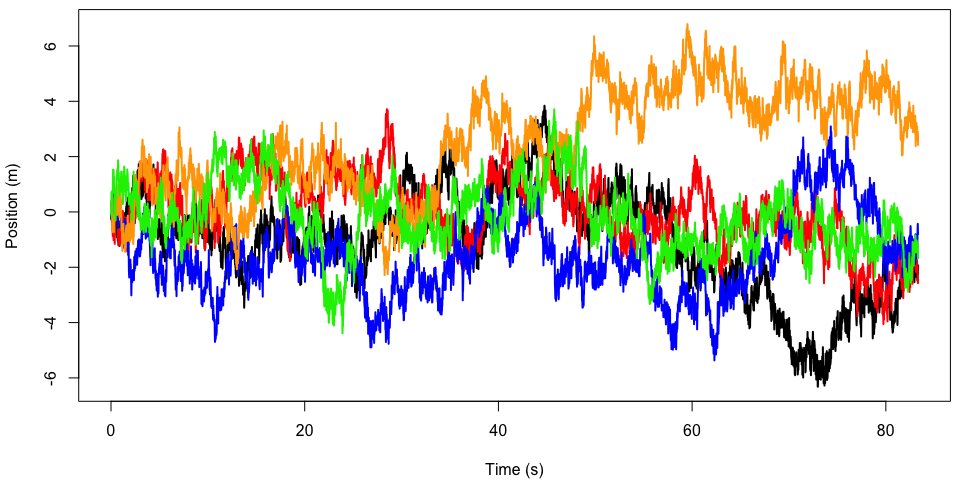

```r
# convert increments to position measurements
Xt <- apply(rbind(0, dX), 2, cumsum)

# plot
clrs <- c("black", "red", "blue", "orange", "green2")
par(mar = c(4.1,4.1,.5,.5))
plot(0, type = "n", xlim = range(tseq), ylim = range(Xt),
     xlab = "Time (s)", ylab = "Position (m)")
for(ii in 1:npaths) {
  lines(tseq, Xt[,ii], col = clrs[ii], lwd = 2)
}
```

## Inference for the Hurst Parameter

### The `Toeplitz` Matrix Class

The bulk of the likelihood calculations in **SuperGauss** are handled by the `Toeplitz` matrix class. A `Toeplitz` object is created as follows:

```r
# allocate and assign in one step
Tz <- Toeplitz$new(acf = acf)
Tz
```

```
## Toeplitz matrix of size 5000
##  acf:  0.0857 -0.0208 -0.00421 -0.00228 -0.0015 -0.00109 ...
```

```r
# allocate memory only
Tz <- Toeplitz$new(N = N)
Tz
```

```
## Toeplitz matrix of size 5000
##  acf:  NULL
```

```r
Tz$set_acf(acf = acf) # assign later
```

Its primary methods are illustrated below:

```r
all(acf == Tz$get_acf()) # extract acf
```

```
## [1] TRUE
```

```r
# matrix multiplication
z <- rnorm(N)
x1 <- toeplitz(acf) %*% z # regular way
x2 <- Tz$prod(z) # with Toeplitz class
x3 <- Tz %*% z # with Toeplitz class overloading the `%*%` operator
range(x1-x2)
```

```
## [1] -2.442491e-15  1.221245e-15
```

```r
range(x2-x3)
```

```
## [1] 0 0
```

```r
# system of equations
y1 <- solve(toeplitz(acf), z) # regular way
y2 <- Tz$solve(z) # with Toeplitz class
y2 <- solve(Tz, z) # same thing but overloading `solve()`
range(y1-y2)
```

```
## [1] -8.917311e-12  1.006129e-11
```

```r
# log-determinant
ld1 <- determinant(toeplitz(acf))$mod
ld2 <- Tz$log_det() # with Toeplitz class
ld2 <- determinant(Tz) # same thing but overloading `determinant()`
                         # note: no $mod
c(ld1, ld2)
```

```
## [1] -12737.89 -12737.89
```

### Maximum Likelihood Calculation

The following code shows how to obtain the maximum likelihood of $H$ and its standard error for a given fBM path. The log-PDF of the Gaussian with Toeplitz variance matrix is obtained either with `SuperGauss::dnormtz()`, or using the `NormalToeplitz` class. The advantage of the latter is that it does not reallocate memory for the underlying `Toeplitz` object at every likelihood evaulation.

For speed comparisons, the optimization underlying the MLE calculation is done both using the superfast Generalized Schur algorithm and the fast Durbin-Levinson algorithm.

```r
dX <- diff(Xt[,1]) # obtain the increments of a given path
N <- length(dX)

# autocorrelation of fBM increments
fbm_acf <- function(H) {
  msd <- fbm_msd(1:N*dT, H = H)
  msd2acf(msd)
}

# loglikelihood using generalized Schur algorithm
NTz <- NormalToeplitz$new(N = N) # pre-allocate memory
loglik_GS <- function(H) {
  NTz$logdens(z = dX, acf = fbm_acf(H))
}

# loglikelihood using Durbin-Levinson algorithm
loglik_DL <- function(H) {
  dnormtz(X = dX, acf = fbm_acf(H), method = "ltz", log = TRUE)
}

# superfast method
system.time({
  GS_mle <- optimize(loglik_GS, interval = c(.01, .99), maximum = TRUE)
})
```

```
##    user  system elapsed
##   0.063   0.002   0.065
```

```r
# fast method (about 10x slower)
system.time({
  DL_mle <- optimize(loglik_DL, interval = c(.01, .99), maximum = TRUE)
})
```

```
##    user  system elapsed
##   0.807   0.001   0.807
```

```r
c(GS = GS_mle$max, DL = DL_mle$max)
```

```
##        GS        DL
## 0.2969185 0.2969185
```

```r
# standard error calculation
require(numDeriv)
Hmle <- GS_mle$max
Hse <- -hessian(func = loglik_GS, x = Hmle) # observed Fisher Information
Hse <- sqrt(1/Hse[1])
c(mle = Hmle, se = Hse)
```

```
##         mle          se
## 0.296918508 0.002582912
```

### Caution with `R6` Classes

In order to effectively manage memory in the underlying **C++** code, the `Toeplitz` class is implemented using [R6 classes](https://r6.r-lib.org/). Among other things, this means that when a `Toeplitz` object is passed to a function, the function does not make a copy of it: all modifications to the object inside the object are reflected on the object outside the function as well, as in the following example:

```r
T1 <- Toeplitz$new(N = N)
T2 <- T1 # shallow copy: both of these point to the same memory location

# affects both objects
T1$set_acf(fbm_acf(.5))
T1
```

```
## Toeplitz matrix of size 5000
##  acf:  0.0167 0 1.73e-18 -3.47e-18 0 6.94e-18 ...
```

```r
T2
```

```
## Toeplitz matrix of size 5000
##  acf:  0.0167 0 1.73e-18 -3.47e-18 0 6.94e-18 ...
```

```r
fbm_logdet <- function(H) {
  T1$set_acf(acf = fbm_acf(H))
  T1$log_det()
}

# affects both objects
fbm_logdet(H = .3)
```

```
## [1] -12737.89
```

```r
T1
```

```
## Toeplitz matrix of size 5000
##  acf:  0.0857 -0.0208 -0.00421 -0.00228 -0.0015 -0.00109 ...
```

```r
T2
```

```
## Toeplitz matrix of size 5000
##  acf:  0.0857 -0.0208 -0.00421 -0.00228 -0.0015 -0.00109 ...
```

To avoid this behavior, it is necessary to make a deep copy of the object:

```r
T3 <- T1$clone(deep = TRUE)
T1
```

```
## Toeplitz matrix of size 5000
##  acf:  0.0857 -0.0208 -0.00421 -0.00228 -0.0015 -0.00109 ...
```

```r
T3
```

```
## Toeplitz matrix of size 5000
##  acf:  0.0857 -0.0208 -0.00421 -0.00228 -0.0015 -0.00109 ...
```

```r
# only affect T1
fbm_logdet(H = .7)
```

```
## [1] -29326.33
```

```r
T1
```

```
## Toeplitz matrix of size 5000
##  acf:  0.00324 0.00104 0.000612 0.000474 0.000397 0.000347 ...
```

```r
T3
```

```
## Toeplitz matrix of size 5000
##  acf:  0.0857 -0.0208 -0.00421 -0.00228 -0.0015 -0.00109 ...
```

## Superfast Newton-Raphson

In addition to the superfast algorithm for Gaussian likelihood evaluations, **SuperGauss** provides such algorithms for the loglikelihood gradient and Hessian functions, leading to superfast versions of many inference algorithms such as Newton-Raphson and Hamiltonian Monte Carlo. These are provided by the `NormalToeplitz$grad()` and `NormalToeplitz$hess()` methods. Both of these methods optionally return the lower order derivatives as well, reusing common computations to improve performance. An example of Newton-Raphson is given below using the two-parameter exponential autocorrelation model
$$\mathrm{\scriptsize ACF}_X(t \mid \lambda, \sigma) = \sigma^2 \exp(- |t/\lambda|).$$
The example uses `stats::nlm()` for optimization, which requires the derivatives to be passsed as attributes to the (negative) loglikelihood.

```r
# autocorrelation function
exp_acf <- function(t, lambda, sigma) sigma^2 * exp(-abs(t/lambda))
# gradient, returned as a 2-column matrix
exp_acf_grad <- function(t, lambda, sigma) {
  ea <- exp_acf(t, lambda, 1)
  cbind(abs(t)*(sigma/lambda)^2 * ea, # d_acf/d_lambda
        2*sigma * ea) # d_acf/d_sigma
}
# Hessian, returned as an array of size length(t) x 2 x 2
exp_acf_hess <- function(t, lambda, sigma) {
  ea <- exp_acf(t, lambda, 1)
  sl2 <- sigma/lambda^2
  hess <- array(NA, dim = c(length(t), 2, 2))
  hess[,1,1] <- sl2^2*(t^2 - 2*abs(t)*lambda) * ea # d2_acf/d_lambda^2
  hess[,1,2] <- 2*sl2 * abs(t) * ea # d2_acf/(d_lambda d_sigma)
  hess[,2,1] <- hess[,1,2] # d2_acf/(d_sigma d_lambda)
  hess[,2,2] <- 2 * ea # d2_acf/d_sigma^2
  hess
}

# simulate data
lambda <- runif(1, .5, 2)
sigma <- runif(1, .5, 2)
tseq <- (1:N-1)*dT
acf <- exp_acf(t = tseq, lambda = lambda, sigma = sigma)
Xt <- rnormtz(acf = acf)

NTz <- NormalToeplitz$new(N = N) # storage space

# negative loglikelihood function of theta = (lambda, sigma)
# include attributes for gradient and Hessian
exp_negloglik <- function(theta) {
  lambda <- theta[1]
  sigma <- theta[2]
  # acf, its gradient, and Hessian
  acf <- exp_acf(tseq, lambda, sigma)
  dacf <- exp_acf_grad(tseq, lambda, sigma)
  d2acf <- exp_acf_hess(tseq, lambda, sigma)
  # derivatives of NormalToeplitz up to order 2
  derivs <- NTz$hess(z = Xt,
                     dz = matrix(0, N, 2),
                     d2z = array(0, dim = c(N, 2, 2)),
                     acf = acf,
                     dacf = dacf,
                     d2acf = d2acf,
                     full_out = TRUE)
  # negative loglikelihood with derivatives as attributes
  nll <- -1 * derivs$ldens
  attr(nll, "gradient") <- -1 * derivs$grad
  attr(nll, "hessian") <- -1 * derivs$hess
  nll
}

# optimization
system.time({
  mle_fit <- nlm(f = exp_negloglik, p = c(1,1), hessian = TRUE)
})
```

```
##    user  system elapsed
##   0.322   0.003   0.326
```

```r
# display estimates with standard errors
rbind(true = c(lambda = lambda, sigma = sigma),
      est = mle_fit$estimate,
      se = sqrt(diag(solve(mle_fit$hessian))))
```

```
##          lambda      sigma
## true 0.62321878 1.06072036
## est  0.54537583 0.98368047
## se   0.06371402 0.05659194
```

## References

Ammar, G.S. and Gragg, W.B., 1988. Superfast solution of real positive definite Toeplitz systems. *SIAM Journal on Matrix Analysis and Applications*, 9 (1), 61–76.

Brockwell, P.J. and Davis, R.A., 1991. *Time series: Theory and methods*. Springer: New York.

Frigo, M. and Johnson, S.G., 2005. The design and implementation of FFTW3. *Proceedings of the IEEE*, 93 (2), 216–231.

Wood, A.T. and Chan, G., 1994. Simulation of stationary gaussian processes in $[0, 1]^d$. *Journal of Computational and Graphical Statistics*, 3 (4), 409–432.